# Course Project

# Title

Feedback Type Prediction Model - Yihong Wang

# Abstract

In this project, we are trying to use the data of left contrast, right contrast,spks, and brain area to predict the outcome of feedback type.

# 1 :Introduction

“Vision, decision-making, and actions arise from neuronal activity across multiple brain regions.The study conducted by Nicholas A. Steinmetz, Peter Zatka-Haas, Matteo Carandini & Kenneth D. Harris in 2019 mapped where these neurons are located in the brain. Researchers used Neuropixels probes to record from about 30,000 neurons across 42 brain regions in mice.The mice performed a visual discrimination task while neural activity was recorded. Neurons encoding visual stimuli and upcoming choices were found mainly in the neocortex, basal ganglia, and midbrain. Choice-related signals were rare and appeared at the same time across different regions.Midbrain neurons were active before contralateral choices and suppressed before ipsilateral choices, while forebrain neurons could prefer either side. Before a stimulus, brain-wide activity predicted engagement, with increased subcortical activity and reduced neocortical activity. These findings reveal how neurons are distributed in the brain to encode behaviorally relevant information.”(summarized by chatgpt based on the nature article’s abstract)

“In the study conducted by Steinmetz et al. (2019), experiments were performed on a total of 10 mice over 39 sessions. Each session comprised several hundred trials, during which visual stimuli were randomly presented to the mouse on two screens positioned on both sides of it. The stimuli varied in terms of contrast levels, which took values in {0, 0.25, 0.5, 1}, with 0 indicating the absence of a stimulus. The mice were required to make decisions based on the visual stimuli, using a wheel controlled by their forepaws. A reward or penalty (i.e., feedback) was subsequently administered based on the outcome of their decisions. In particular,

When left contrast > right contrast, success (1) if turning the wheel to the right and failure (-1) otherwise. When right contrast > left contrast, success (1) if turning the wheel to the left and failure (-1) otherwise. When both left and right contrasts are zero, success (1) if holding the wheel still and failure (-1) otherwise. When left and right contrasts are equal but non-zero, left or right will be randomly chosen (50%) as the correct choice. The activity of the neurons in the mice’s visual cortex was recorded during the trials and made available in the form of spike trains, which are collections of timestamps corresponding to neuron firing. In this project, we focus specifically on the spike trains of neurons from the onset of the stimuli to 0.4 seconds post-onset. In addition, we only use 18 sessions (Sessions 1 to 18) from four mice: Cori, Frossman, Hence, and Lederberg.”

```r
#install.packages("Matrix")
#install.packages("ROCR")
```

```r
library(tidyverse)
```

```r
library(dplyr)
library(ggplot2)
library(readr)
library(tidyverse)
library(caret)
library(ROCR)
```

# 2 Exploratory analysis

-What are some interesting patterns of the data, especially the similarity and difference among different observations (trails). This will answer the question of how to select our training samples. -What patterns make a trail more likely to have a successful respinse. This will answer the question of how to build our training features.

### summarizing the data

```r
sessions=list()
for(i in 1:18){
  sessions[[i]]=readRDS(paste('/Users/sophiawang/Desktop/stat141/sessions/session',i,'.rds',sep=''))
}
```

```r
summary_list <- lapply(1:18, function(i) {
  df <- as.data.frame(summary(sessions[[i]]))
  df <- cbind(Variable = rownames(df), df)  # Keep variable names
  df$Sessions <- paste("Session", i)  # Add session ID
  rownames(df) <- NULL  # Reset row names for clarity
  return(df)
})

summary_list[[1]]
```

```
##    Variable           Var1   Var2      Freq  Sessions
## 1         1  contrast_left Length       114 Session 1
## 2         2 contrast_right Length       114 Session 1
## 3         3  feedback_type Length       114 Session 1
## 4         4     mouse_name Length         1 Session 1
## 5         5     brain_area Length       734 Session 1
## 6         6       date_exp Length         1 Session 1
## 7         7           spks Length       114 Session 1
## 8         8           time Length       114 Session 1
## 9         9  contrast_left  Class    -none- Session 1
## 10       10 contrast_right  Class    -none- Session 1
## 11       11  feedback_type  Class    -none- Session 1
## 12       12     mouse_name  Class    -none- Session 1
## 13       13     brain_area  Class    -none- Session 1
## 14       14       date_exp  Class    -none- Session 1
## 15       15           spks  Class    -none- Session 1
## 16       16           time  Class    -none- Session 1
## 17       17  contrast_left   Mode   numeric Session 1
## 18       18 contrast_right   Mode   numeric Session 1
## 19       19  feedback_type   Mode   numeric Session 1
## 20       20     mouse_name   Mode character Session 1
## 21       21     brain_area   Mode character Session 1
## 22       22       date_exp   Mode character Session 1
## 23       23           spks   Mode      list Session 1
## 24       24           time   Mode      list Session 1
```

```r
summary_list[[5]]
```

```
##    Variable           Var1   Var2      Freq  Sessions
## 1         1  contrast_left Length       254 Session 5
## 2         2 contrast_right Length       254 Session 5
## 3         3  feedback_type Length       254 Session 5
## 4         4     mouse_name Length         1 Session 5
## 5         5     brain_area Length      1077 Session 5
## 6         6       date_exp Length         1 Session 5
## 7         7           spks Length       254 Session 5
## 8         8           time Length       254 Session 5
## 9         9  contrast_left  Class    -none- Session 5
## 10       10 contrast_right  Class    -none- Session 5
## 11       11  feedback_type  Class    -none- Session 5
## 12       12     mouse_name  Class    -none- Session 5
## 13       13     brain_area  Class    -none- Session 5
## 14       14       date_exp  Class    -none- Session 5
## 15       15           spks  Class    -none- Session 5
## 16       16           time  Class    -none- Session 5
## 17       17  contrast_left   Mode   numeric Session 5
## 18       18 contrast_right   Mode   numeric Session 5
## 19       19  feedback_type   Mode   numeric Session 5
## 20       20     mouse_name   Mode character Session 5
## 21       21     brain_area   Mode character Session 5
## 22       22       date_exp   Mode character Session 5
## 23       23           spks   Mode      list Session 5
## 24       24           time   Mode      list Session 5
```

```r
summary_list[[10]]
```

```
##    Variable           Var1   Var2      Freq   Sessions
## 1         1  contrast_left Length       447 Session 10
## 2         2 contrast_right Length       447 Session 10
## 3         3  feedback_type Length       447 Session 10
## 4         4     mouse_name Length         1 Session 10
## 5         5     brain_area Length      1172 Session 10
## 6         6       date_exp Length         1 Session 10
## 7         7           spks Length       447 Session 10
## 8         8           time Length       447 Session 10
## 9         9  contrast_left  Class    -none- Session 10
## 10       10 contrast_right  Class    -none- Session 10
## 11       11  feedback_type  Class    -none- Session 10
## 12       12     mouse_name  Class    -none- Session 10
## 13       13     brain_area  Class    -none- Session 10
## 14       14       date_exp  Class    -none- Session 10
## 15       15           spks  Class    -none- Session 10
## 16       16           time  Class    -none- Session 10
## 17       17  contrast_left   Mode   numeric Session 10
## 18       18 contrast_right   Mode   numeric Session 10
## 19       19  feedback_type   Mode   numeric Session 10
## 20       20     mouse_name   Mode character Session 10
## 21       21     brain_area   Mode character Session 10
## 22       22       date_exp   Mode character Session 10
## 23       23           spks   Mode      list Session 10
## 24       24           time   Mode      list Session 10
```

```r
summary_list[[18]]
```

```
##    Variable           Var1   Var2      Freq   Sessions
## 1         1  contrast_left Length       216 Session 18
## 2         2 contrast_right Length       216 Session 18
## 3         3  feedback_type Length       216 Session 18
## 4         4     mouse_name Length         1 Session 18
## 5         5     brain_area Length      1090 Session 18
## 6         6       date_exp Length         1 Session 18
## 7         7           spks Length       216 Session 18
## 8         8           time Length       216 Session 18
## 9         9  contrast_left  Class    -none- Session 18
## 10       10 contrast_right  Class    -none- Session 18
## 11       11  feedback_type  Class    -none- Session 18
## 12       12     mouse_name  Class    -none- Session 18
## 13       13     brain_area  Class    -none- Session 18
## 14       14       date_exp  Class    -none- Session 18
## 15       15           spks  Class    -none- Session 18
## 16       16           time  Class    -none- Session 18
## 17       17  contrast_left   Mode   numeric Session 18
## 18       18 contrast_right   Mode   numeric Session 18
## 19       19  feedback_type   Mode   numeric Session 18
## 20       20     mouse_name   Mode character Session 18
## 21       21     brain_area   Mode character Session 18
## 22       22       date_exp   Mode character Session 18
## 23       23           spks   Mode      list Session 18
## 24       24           time   Mode      list Session 18
```

### What’s in a session?

```r
names(sessions[[1]])
```

```
## [1] "contrast_left"  "contrast_right" "feedback_type"  "mouse_name"
## [5] "brain_area"     "date_exp"       "spks"           "time"
```

feedback_type: Numerous instances indicate success, but potential issues may exist. contrast_left and contrast_right: Present in four distinct scenarios. In particular, When left contrast > right contrast, success (1) if turning the wheel to the right and failure (-1) otherwise. When right contrast > left contrast, success (1) if turning the wheel to the left and failure (-1) otherwise. When both left and right contrasts are zero, success (1) if holding the wheel still and failure (-1) otherwise. When left and right contrasts are equal but non-zero, left or right will be randomly chosen (50%) as the correct choice. mouse_name: Influenced by four factors. date_exp: May not be directly correlated with success. brain_area: Comprised of multiple factors; consideration for reduction to a smaller set of factors may be beneficial. spks: Matrix of dimensions time: Vector of dimension q across sessions for number of trials Ni.

### what’s in a trail?

```r
dim(sessions[[1]]$spks[[1]])
```

```
## [1] 734  40
```

```r
length(sessions[[1]]$brain_area)
```

```
## [1] 734
```

```r
sessions[[1]]$spks[[1]][6,]
```

```
##  [1] 0 0 1 0 0 0 1 0 0 0 0 0 0 0 0 0 0 0 0 0 0 0 1 0 0 0 0 0 0 0 0 0 0 0 0 0 0 0
## [39] 0 0
```

The first and second command show that the dimension of spks is 734 rows and 40 columns. which means there are 734 recorded neurons in 40 recorded time point.

The third command extracts a specific trail, in this case the 6th row of spks matrix.The row consists 0s and 1s, indicating some neurons were actived and some are not.

### How to connect the neuron spike with brian region?

```r
sessions[[1]]$spks[[1]][6,3]
```

```
## [1] 1
```

```r
sessions[[1]]$brain_area[6]
```

```
## [1] "ACA"
```

I denote the spike rate per neuron as the sum of spikes over the 40 time bins. The region_mean_spike records the average of spike rate over each region.

```r
get_trail_data <- function(session_id, trail_id){
  spikes <- sessions[[session_id]]$spks[[trail_id]]
  if (any(is.na(spikes))){
    disp("value missing")
  }

  #trail_tibble <- as_tibble(spikes) %>% set_names(binename) %>%  add_column("brain_area" = session[[session_id]]$brain_area ) %>% group_by(brain_area) %>% summarize( "sum_spikes" =across(everything(),sum),.groups = "drop")
  trail_tibble <- tibble("neuron_spike" = rowSums(spikes))  %>%  add_column("brain_area" = sessions[[session_id]]$brain_area ) %>% group_by(brain_area) %>% summarize( region_sum_spike = sum(neuron_spike), region_count = n(),region_mean_spike = mean(neuron_spike))
  trail_tibble  = trail_tibble%>% add_column("trail_id" = trail_id) %>% add_column("contrast_left"= sessions[[session_id]]$contrast_left[trail_id]) %>% add_column("contrast_right"= sessions[[session_id]]$contrast_right[trail_id]) %>% add_column("feedback_type"= sessions[[session_id]]$feedback_type[trail_id])
  trail_tibble
}
```

```r
trail_tibble_1_2 <- get_trail_data(1,2)
trail_tibble_1_2
```

```
## # A tibble: 8 × 8
##   brain_area region_sum_spike region_count region_mean_spike trail_id
##   <chr>                 <dbl>        <int>             <dbl>    <dbl>
## 1 ACA                      64          109             0.587        2
## 2 CA3                     116           68             1.71         2
## 3 DG                       53           34             1.56         2
## 4 LS                      190          139             1.37         2
## 5 MOs                      88          113             0.779        2
## 6 SUB                     146           75             1.95         2
## 7 VISp                    294          178             1.65         2
## 8 root                     12           18             0.667        2
## # ℹ 3 more variables: contrast_left <dbl>, contrast_right <dbl>,
## #   feedback_type <dbl>
```

###What are the number of neuron’s in each session?

```r
library(dplyr)

# Create a tibble with session IDs and neuron counts
neuron_counts <- tibble(
  session_id = 1:length(sessions),  # Assign session numbers
  region_count = sapply(sessions, function(session) length(session$brain_area))
)

# Print the table
print(neuron_counts)
```

```
## # A tibble: 18 × 2
##    session_id region_count
##         <int>        <int>
##  1          1          734
##  2          2         1070
##  3          3          619
##  4          4         1769
##  5          5         1077
##  6          6         1169
##  7          7          584
##  8          8         1157
##  9          9          788
## 10         10         1172
## 11         11          857
## 12         12          698
## 13         13          983
## 14         14          756
## 15         15          743
## 16         16          474
## 17         17          565
## 18         18         1090
```

###What is the number brain area of each session?

```r
library(dplyr)

# Create a tibble with session IDs and brain area counts
brain_area_counts <- tibble(
  session_id = 1:length(sessions),  # Assign session numbers
  brain_area_count = sapply(sessions, function(session) length(unique(session$brain_area)))
)

# Print the table
print(brain_area_counts)
```

```
## # A tibble: 18 × 2
##    session_id brain_area_count
##         <int>            <int>
##  1          1                8
##  2          2                5
##  3          3               11
##  4          4               11
##  5          5               10
##  6          6                5
##  7          7                8
##  8          8               15
##  9          9               12
## 10         10               13
## 11         11                6
## 12         12               12
## 13         13               15
## 14         14               10
## 15         15                8
## 16         16                6
## 17         17                6
## 18         18               10
```

###What is the average spike rate over each session?

```r
library(dplyr)

# Compute average spike rate for each session
avg_spike_rates <- tibble(
  session_id = 1:length(sessions),  # Assign session numbers
  avg_spike_rate = sapply(sessions, function(session) {
    mean(unlist(session$spks), na.rm = TRUE)  # Flatten and compute mean of spike rates
  })
)

# Print the result
print(avg_spike_rates)
```

```
## # A tibble: 18 × 2
##    session_id avg_spike_rate
##         <int>          <dbl>
##  1          1         0.0385
##  2          2         0.0316
##  3          3         0.0558
##  4          4         0.0210
##  5          5         0.0279
##  6          6         0.0166
##  7          7         0.0354
##  8          8         0.0414
##  9          9         0.0397
## 10         10         0.0297
## 11         11         0.0313
## 12         12         0.0416
## 13         13         0.0614
## 14         14         0.0252
## 15         15         0.0366
## 16         16         0.0263
## 17         17         0.0291
## 18         18         0.0274
```

###What are the brain areas with neurons recorded in each session?

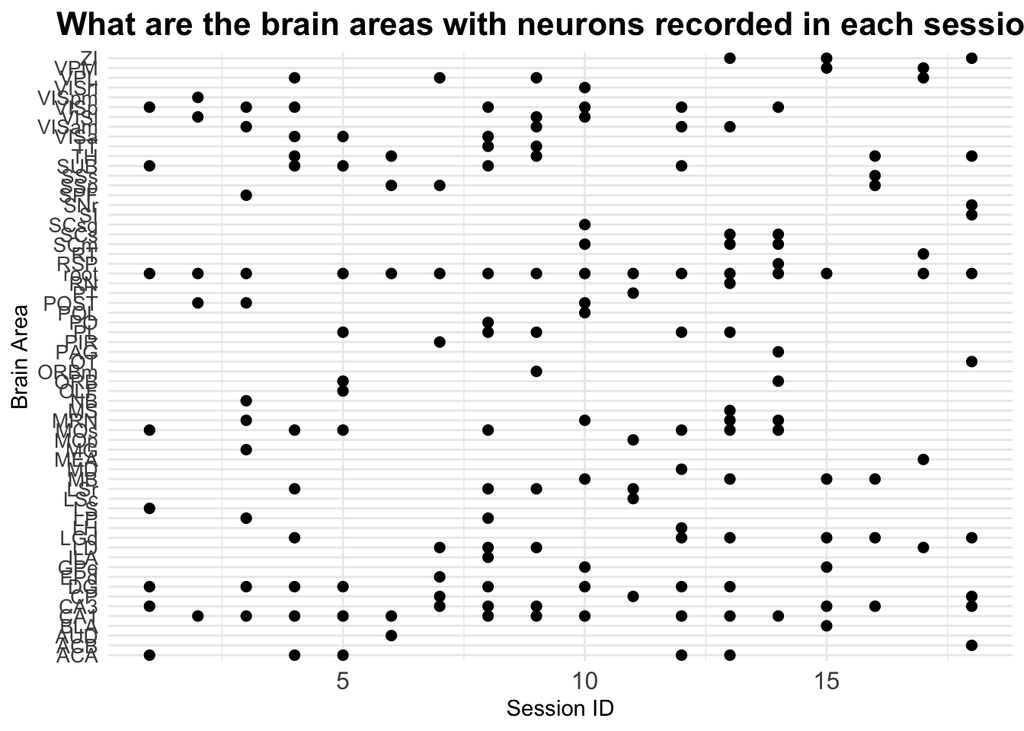

```r
library(ggplot2)
library(dplyr)

# Create a data frame summarizing brain areas per session
brain_area_data <- bind_rows(lapply(1:length(sessions), function(i) {
  data.frame(
    session_id = i,
    brain_area = unique(sessions[[i]]$brain_area)  # Extract unique brain areas per session
  )
}))

# Plot brain areas recorded per session
ggplot(brain_area_data, aes(x = session_id, y = brain_area)) +
  geom_point(color = "black", size = 2) +  # Scatter plot of brain areas
  theme_minimal() +
  labs(title = "What are the brain areas with neurons recorded in each session?",
       x = "Session ID",
       y = "Brain Area") +
  theme(plot.title = element_text(face = "bold", size = 16, hjust = 0.5),  # Bold and centered title
        axis.text.x = element_text(size = 12),
        axis.text.y = element_text(size = 10))
```

-The vertical axis represents the names of the brain areas, the horizontal axis represents number of sessions.From this graph we can see the distribution of the brain areas across sessions. Each dot represents a brain area recorded in a specific session.

-Variability of the brain areas–Some of the brain areas may appear multiple times in one session and may appears in multiple sessions.

-Diversity of the brain areas–Some sessions contain recorded more brain areas than others.

###Estimate success rate over different groups (session and mouse)

```r
success_rate_session <- bind_rows(lapply(1:length(sessions), function(i) {
  data.frame(
    session_id = i,
    success_rate = mean(sessions[[i]]$feedback_type == 1)  # Proportion of successful trials
  )
}))


success_rate_mouse <- bind_rows(lapply(unique(sapply(sessions, function(x) x$mouse_name)), function(mouse) {
  data.frame(
    mouse_name = mouse,
    success_rate = mean(unlist(lapply(sessions, function(session) {
      if (session$mouse_name == mouse) session$feedback_type == 1 else NA
    })), na.rm = TRUE)  # Proportion of successful trials per mouse
  )
}))
```

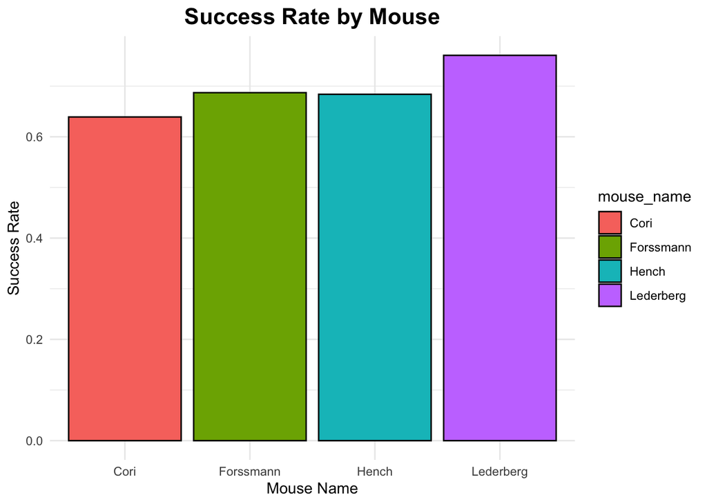

```r
ggplot(success_rate_mouse, aes(x = mouse_name, y = success_rate, fill = mouse_name)) +
  geom_bar(stat = "identity", color = "black") +
  theme_minimal() +
  labs(title = "Success Rate by Mouse",
       x = "Mouse Name",
       y = "Success Rate") +
  theme(plot.title = element_text(face = "bold", size = 16, hjust = 0.5))
```

##What is different among each trail? ###What is the contrast difference distribution?

```r
# Compute the contrast difference
contrast_data <- bind_rows(lapply(sessions, function(session) {
  data.frame(contrast_diff = abs(session$contrast_left - session$contrast_right))
}))

# Summarize the contrast difference distribution
contrast_distribution <- contrast_data %>%
  group_by(contrast_diff) %>%
  summarise(n = n()) %>%
  mutate(
    perc = n / sum(n),  # Compute percentage
    labels = paste0(round(perc * 100, 2), "%")  # Format percentage as a label
  ) %>%
  arrange(desc(n))  # Sort by frequency

# Print the table
print(contrast_distribution)
```

```
## # A tibble: 5 × 4
##   contrast_diff     n  perc labels
##           <dbl> <int> <dbl> <chr>
## 1          0     1686 0.332 33.18%
## 2          0.5   1045 0.206 20.57%
## 3          1      892 0.176 17.56%
## 4          0.75   740 0.146 14.56%
## 5          0.25   718 0.141 14.13%
```

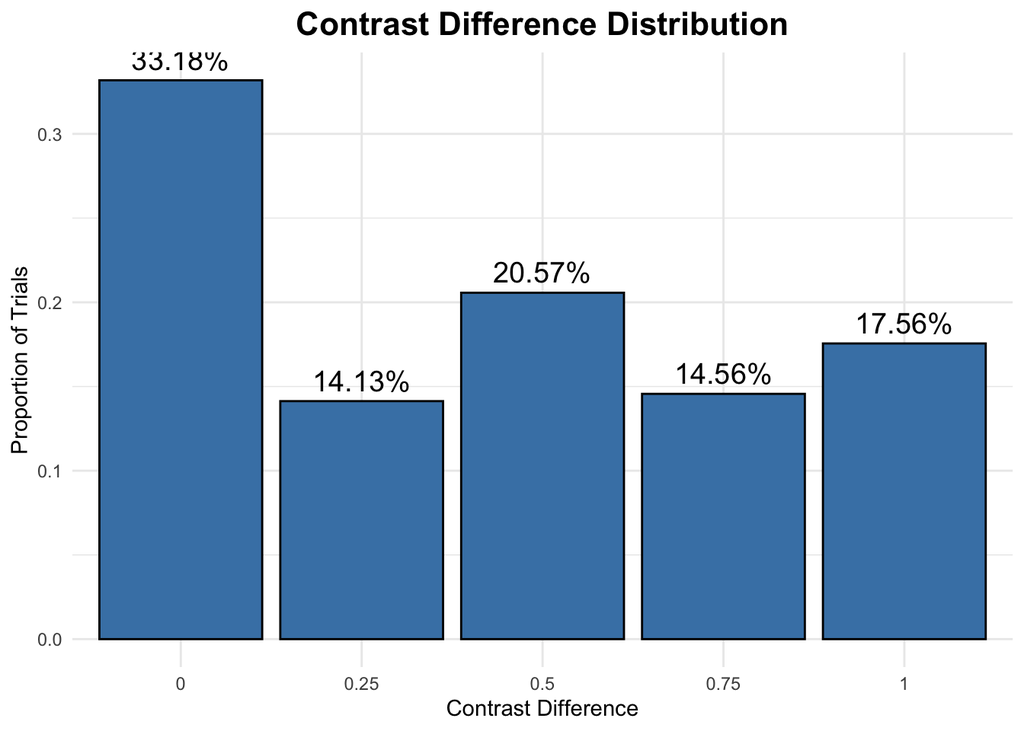

```r
ggplot(contrast_distribution, aes(x = factor(contrast_diff), y = perc)) +
  geom_bar(stat = "identity", fill = "steelblue", color = "black") +
  geom_text(aes(label = labels), vjust = -0.5, size = 5) +  # Add percentage labels
  theme_minimal() +
  labs(title = "Contrast Difference Distribution",
       x = "Contrast Difference",
       y = "Proportion of Trials") +
  theme(plot.title = element_text(face = "bold", size = 16, hjust = 0.5))
```

- what is contrast difference: “The contrast difference refers to the absolute difference between the contrast levels presented on two sides of a visual stimulus”, in this case left contrast and right contrast. So that when contrast difference equals 0, both sides have the same contrast, meaning the decision making is randomly presented.

-why it’s important to look at: “A well-balanced experiment includes a mix of high, medium, and low contrast differences.”

-33.18% of the trials have zero contrast difference. 20.57% of the trails have moderate contrast differences. In total of 32.12%(17.56% + 14.56%) of the trails have higher contrast differences. 14.13%. of the trails have low contrast differences. Bease on these numbers we could tell this is a well-balanced experiment.

###How does the contrast difference affect the success rate?

```r
# Compute contrast difference
contrast_success_data <- bind_rows(lapply(sessions, function(session) {
  data.frame(
    contrast_diff = abs(session$contrast_left - session$contrast_right),
    success = ifelse(session$feedback_type == 1, 1, 0)  # Convert feedback_type to binary success indicator
  )
}))

# Compute success rate for each contrast difference
contrast_success_summary <- contrast_success_data %>%
  group_by(contrast_diff) %>%
  summarise(success_rate = mean(success)) %>%
  arrange(contrast_diff)  # Sort by contrast difference

# Print the table
print(contrast_success_summary)
```

```
## # A tibble: 5 × 2
##   contrast_diff success_rate
##           <dbl>        <dbl>
## 1          0           0.629
## 2          0.25        0.667
## 3          0.5         0.777
## 4          0.75        0.741
## 5          1           0.795
```

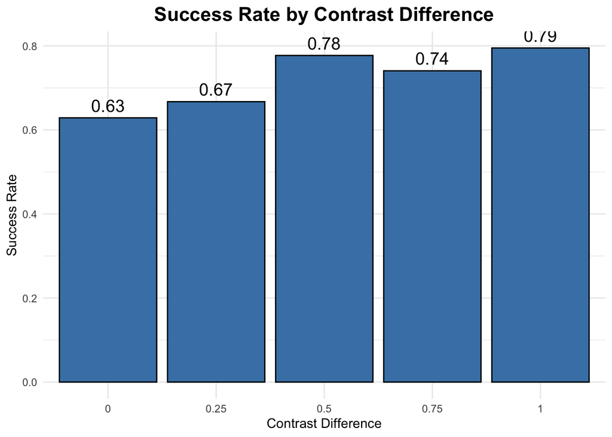

```r
# Load necessary library
library(ggplot2)

# Plot the success rate for each contrast difference
ggplot(contrast_success_summary, aes(x = factor(contrast_diff), y = success_rate)) +
  geom_bar(stat = "identity", fill = "steelblue", color = "black") +
  geom_text(aes(label = round(success_rate, 2)), vjust = -0.5, size = 5) +  # Add success rate labels
  theme_minimal() +
  labs(title = "Success Rate by Contrast Difference",
       x = "Contrast Difference",
       y = "Success Rate") +
  theme(plot.title = element_text(face = "bold", size = 16, hjust = 0.5))
```

-When contrast difference equals 0.00, the success rate is 62.87%. When contrast difference equals 0.50, the success rate is 77.70%. When contrast difference equals 1, the success rate is 79%. Based on the significant increases of success rate along with the increase in contrast difference, we can conclude that contrast difference strongly affects success rate.

###Does the success rate difference among mice caused by the different distributions of contrast difference?

```r
# Compute contrast difference and success indicator for each mouse
contrast_mouse_data <- bind_rows(lapply(sessions, function(session) {
  data.frame(
    mouse_name = session$mouse_name,  # Extract mouse name
    contrast_diff = abs(session$contrast_left - session$contrast_right),  # Compute contrast difference
    success = ifelse(session$feedback_type == 1, 1, 0)  # Convert feedback_type to binary success indicator
  )
}))

# Compute success rate for each contrast difference and mouse
contrast_mouse_summary <- contrast_mouse_data %>%
  group_by(mouse_name, contrast_diff) %>%
  summarise(success_rate = mean(success), .groups = "drop") %>%
  pivot_wider(names_from = contrast_diff, values_from = success_rate)  # Reshape for a table format

# Print the table
print(contrast_mouse_summary)
```

```
## # A tibble: 4 × 6
##   mouse_name   `0` `0.25` `0.5` `0.75`   `1`
##   <chr>      <dbl>  <dbl> <dbl>  <dbl> <dbl>
## 1 Cori       0.619  0.635 0.725  0.551 0.648
## 2 Forssmann  0.691  0.548 0.709  0.763 0.802
## 3 Hench      0.648  0.568 0.736  0.672 0.755
## 4 Lederberg  0.586  0.838 0.853  0.813 0.892
```

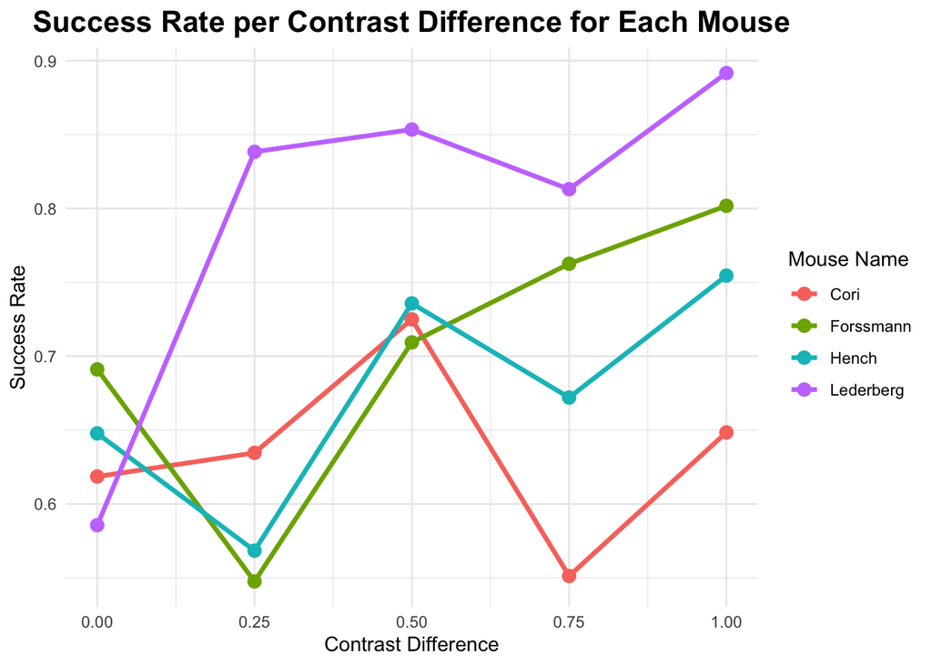

```r
ggplot(contrast_mouse_data, aes(x = contrast_diff, y = success, color = mouse_name)) +
  stat_summary(fun = mean, geom = "line", size = 1.2) +
  stat_summary(fun = mean, geom = "point", size = 3) +
  theme_minimal() +
  labs(title = "Success Rate per Contrast Difference for Each Mouse",
       x = "Contrast Difference",
       y = "Success Rate",
       color = "Mouse Name") +
  theme(plot.title = element_text(face = "bold", size = 16, hjust = 0.5))
```

```r
# Create a data frame combining all session data
success_rate_data <- bind_rows(lapply(seq_along(sessions), function(i) {
  session <- sessions[[i]]
  data.frame(
    session_id = i,  # Store session number
    trial_id = seq_along(session$feedback_type),  # Trial indices
    success = ifelse(session$feedback_type == 1, 1, 0)  # Convert feedback to success indicator
  )
}))

# Bin trials into groups of 25
success_rate_data <- success_rate_data %>%
  mutate(trial_group = ceiling(trial_id / 25)) %>%
  group_by(session_id, trial_group) %>%
  summarise(success_rate = mean(success), .groups = "drop")

# View sample of processed data
head(success_rate_data)
```

```
## # A tibble: 6 × 3
##   session_id trial_group success_rate
##        <int>       <dbl>        <dbl>
## 1          1           1        0.64
## 2          1           2        0.8
## 3          1           3        0.64
## 4          1           4        0.56
## 5          1           5        0.214
## 6          2           1        0.64
```

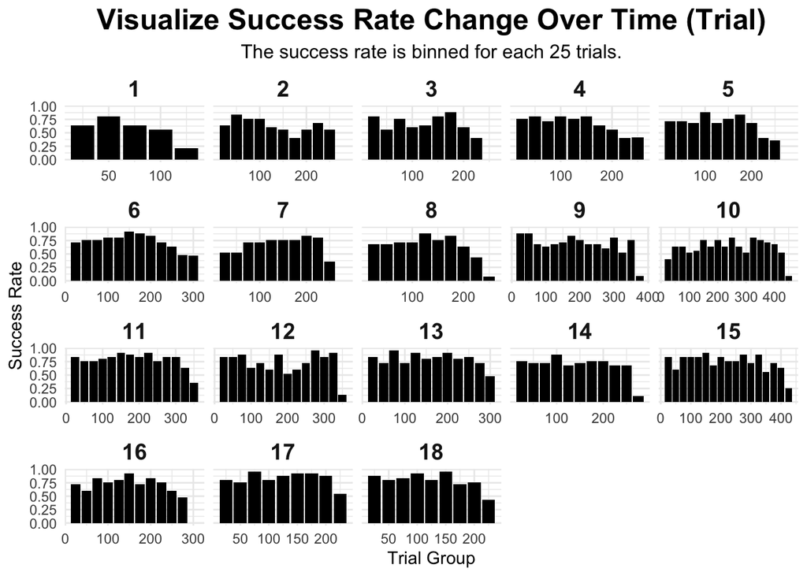

```r
library(ggplot2)

# Plot success rate over trial bins for each session
ggplot(success_rate_data, aes(x = trial_group * 25, y = success_rate)) +
  geom_bar(stat = "identity", fill = "black") +  # Bar plot
  facet_wrap(~ session_id, scales = "free_x") +  # Facet by session
  theme_minimal() +
  labs(title = "Visualize Success Rate Change Over Time (Trial)",
       subtitle = "The success rate is binned for each 25 trials.",
       x = "Trial Group",
       y = "Success Rate") +
  theme(strip.text = element_text(face = "bold", size = 14),
        plot.title = element_text(face = "bold", size = 18, hjust = 0.5),
        plot.subtitle = element_text(size = 12, hjust = 0.5))
```

```r
# Create a data frame combining all session data
success_rate_mouse <- bind_rows(lapply(seq_along(sessions), function(i) {
  session <- sessions[[i]]
  data.frame(
    mouse_name = session$mouse_name,  # Store mouse name
    trial_id = seq_along(session$feedback_type),  # Trial indices
    success = ifelse(session$feedback_type == 1, 1, 0)  # Convert feedback to success indicator
  )
}))

# Bin trials into groups of 25
success_rate_mouse <- success_rate_mouse %>%
  mutate(trial_group = ceiling(trial_id / 25)) %>%
  group_by(mouse_name, trial_group) %>%
  summarise(success_rate = mean(success), .groups = "drop")

# View sample of processed data
head(success_rate_mouse)
```

```
## # A tibble: 6 × 3
##   mouse_name trial_group success_rate
##   <chr>            <dbl>        <dbl>
## 1 Cori                 1        0.693
## 2 Cori                 2        0.733
## 3 Cori                 3        0.72
## 4 Cori                 4        0.64
## 5 Cori                 5        0.531
## 6 Cori                 6        0.68
```

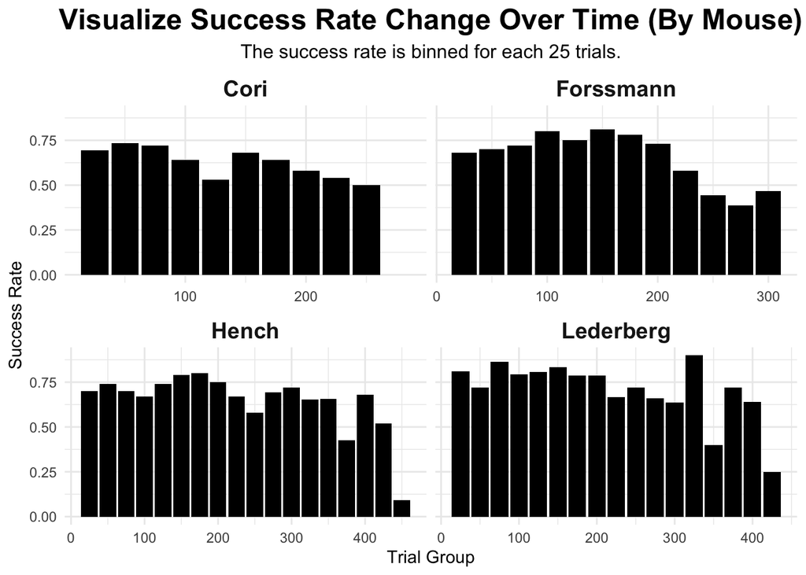

```r
library(ggplot2)

# Plot success rate over trial bins for each mouse
ggplot(success_rate_mouse, aes(x = trial_group * 25, y = success_rate)) +
  geom_bar(stat = "identity", fill = "black") +  # Bar plot
  facet_wrap(~ mouse_name, scales = "free_x") +  # Facet by mouse_name
  theme_minimal() +
  labs(title = "Visualize Success Rate Change Over Time (By Mouse)",
       subtitle = "The success rate is binned for each 25 trials.",
       x = "Trial Group",
       y = "Success Rate") +
  theme(strip.text = element_text(face = "bold", size = 14),
        plot.title = element_text(face = "bold", size = 18, hjust = 0.5),
        plot.subtitle = element_text(size = 12, hjust = 0.5))
```

```r
# Create a data frame for spike rate analysis
spike_rate_data <- bind_rows(lapply(seq_along(sessions), function(i) {
  session <- sessions[[i]]
  mean_spike_rate <- sapply(session$spks, function(trial_spikes) mean(rowSums(trial_spikes, na.rm = TRUE)))

  data.frame(
    session_id = i,  # Add session number
    trial_id = seq_along(mean_spike_rate),  # Trial indices
    mean_spike = mean_spike_rate  # Mean spike per trial
  )
}))

# View a sample of processed data
head(spike_rate_data)
```

```
##   session_id trial_id mean_spike
## 1          1        1   1.581744
## 2          1        2   1.311989
## 3          1        3   1.844687
## 4          1        4   1.381471
## 5          1        5   1.425068
## 6          1        6   1.094005
```

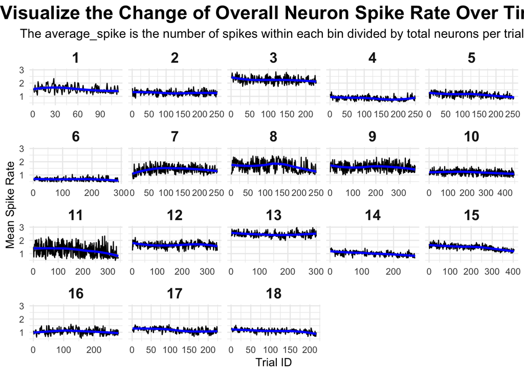

```r
library(ggplot2)

# Plot mean spike rate per trial for each session
ggplot(spike_rate_data, aes(x = trial_id, y = mean_spike)) +
  geom_line(color = "black") +  # Raw spike rate trends
  geom_smooth(method = "loess", color = "blue") +  # Smoothed trendline
  facet_wrap(~ session_id, scales = "free_x") +  # Facet by session
  theme_minimal() +
  labs(title = "Visualize the Change of Overall Neuron Spike Rate Over Time",
       subtitle = "The average_spike is the number of spikes within each bin divided by total neurons per trial.",
       x = "Trial ID",
       y = "Mean Spike Rate") +
  theme(strip.text = element_text(face = "bold", size = 14),
        plot.title = element_text(face = "bold", size = 18, hjust = 0.5),
        plot.subtitle = element_text(size = 12, hjust = 0.5))
```

###The change of overall neuron spike rate for each mouse

```r
# Create a data frame for spike rate analysis grouped by mouse
spike_rate_mouse <- bind_rows(lapply(seq_along(sessions), function(i) {
  session <- sessions[[i]]
  mean_spike_rate <- sapply(session$spks, function(trial_spikes) mean(rowSums(trial_spikes, na.rm = TRUE)))

  data.frame(
    mouse_name = session$mouse_name,  # Mouse identifier
    trial_id = seq_along(mean_spike_rate),  # Trial indices
    mean_spike = mean_spike_rate  # Mean spike per trial
  )
}))

# View a sample of processed data
head(spike_rate_mouse)
```

```
##   mouse_name trial_id mean_spike
## 1       Cori        1   1.581744
## 2       Cori        2   1.311989
## 3       Cori        3   1.844687
## 4       Cori        4   1.381471
## 5       Cori        5   1.425068
## 6       Cori        6   1.094005
```

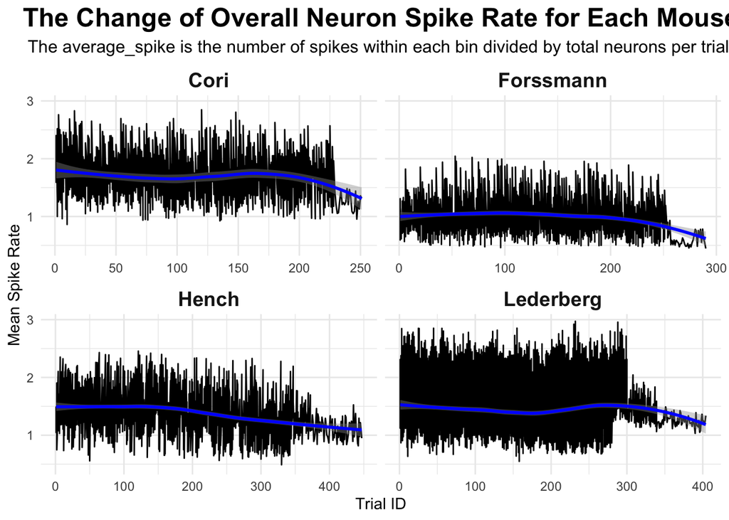

```r
library(ggplot2)

# Plot mean spike rate per trial for each mouse
ggplot(spike_rate_mouse, aes(x = trial_id, y = mean_spike)) +
  geom_line(color = "black") +  # Raw spike rate trends
  geom_smooth(method = "loess", color = "blue") +  # Smoothed trendline
  facet_wrap(~ mouse_name, scales = "free_x") +  # Facet by mouse
  theme_minimal() +
  labs(title = "The Change of Overall Neuron Spike Rate for Each Mouse",
       subtitle = "The average_spike is the number of spikes within each bin divided by total neurons per trial.",
       x = "Trial ID",
       y = "Mean Spike Rate") +
  theme(strip.text = element_text(face = "bold", size = 14),
        plot.title = element_text(face = "bold", size = 18, hjust = 0.5),
        plot.subtitle = element_text(size = 12, hjust = 0.5))
```

# 3 Data integration

```r
library(tidyverse)
library(dplyr)
library(ggplot2)
library(readr)
library(tidyverse)
library(caret)
library(ROCR)
```

### summarizing the data

```r
sessions=list()
for(i in 1:18){
  sessions[[i]]=readRDS(paste('../sessions/session',i,'.rds',sep=''))
}
```

```r
summary_list <- lapply(1:18, function(i) {
  df <- as.data.frame(summary(sessions[[i]]))
  df <- cbind(Variable = rownames(df), df)  # Keep variable names
  df$Sessions <- paste("Session", i)  # Add session ID
  rownames(df) <- NULL  # Reset row names for clarity
  return(df)
})

summary_list[[1]]
```

```
##    Variable           Var1   Var2      Freq  Sessions
## 1         1  contrast_left Length       114 Session 1
## 2         2 contrast_right Length       114 Session 1
## 3         3  feedback_type Length       114 Session 1
## 4         4     mouse_name Length         1 Session 1
## 5         5     brain_area Length       734 Session 1
## 6         6       date_exp Length         1 Session 1
## 7         7           spks Length       114 Session 1
## 8         8           time Length       114 Session 1
## 9         9  contrast_left  Class    -none- Session 1
## 10       10 contrast_right  Class    -none- Session 1
## 11       11  feedback_type  Class    -none- Session 1
## 12       12     mouse_name  Class    -none- Session 1
## 13       13     brain_area  Class    -none- Session 1
## 14       14       date_exp  Class    -none- Session 1
## 15       15           spks  Class    -none- Session 1
## 16       16           time  Class    -none- Session 1
## 17       17  contrast_left   Mode   numeric Session 1
## 18       18 contrast_right   Mode   numeric Session 1
## 19       19  feedback_type   Mode   numeric Session 1
## 20       20     mouse_name   Mode character Session 1
## 21       21     brain_area   Mode character Session 1
## 22       22       date_exp   Mode character Session 1
## 23       23           spks   Mode      list Session 1
## 24       24           time   Mode      list Session 1
```

Extracting the data for contrast_left, contrast right, mouse_name, in each sessions, and name them as x data, keeping separate lists for each session while saving them as a combined data frame.

```r
# Initialize an empty list to store extracted features
x_feature_data <- list()

# Loop through each session and extract the required features
for (i in 1:18) {
  session_data <- sessions[[i]]  # Get the current session data

  # Extract features
  contrast_left <- session_data$contrast_left
  contrast_right <- session_data$contrast_right
  mouse_name <- rep(session_data$mouse_name, length(contrast_left))  # Repeat to match the length

  # Combine extracted features into a data frame
  session_df <- data.frame(
    contrast_left = contrast_left,
    contrast_right = contrast_right,
    mouse_name = mouse_name,
    session = i  # Add session ID for tracking
  )

  # Append to list
  x_feature_data[[i]] <- session_df
}

# Combine all session data into a single data frame
x_feature_data <- do.call(rbind, x_feature_data)

# Print the first few rows of the integrated data
head(x_feature_data)
```

```
##   contrast_left contrast_right mouse_name session
## 1           0.0            0.5       Cori       1
## 2           0.0            0.0       Cori       1
## 3           0.5            1.0       Cori       1
## 4           0.0            0.0       Cori       1
## 5           0.0            0.0       Cori       1
## 6           0.0            0.0       Cori       1
```

Extracting the feedback type from all sessions, and combine them as y data.

```r
# Initialize an empty list to store feedback type
y_label_data <- list()

# Loop through each session and extract the feedback type
for (i in 1:18) {
  session_data <- sessions[[i]]  # Get the current session data

  # Extract feedback type
  feedback_type <- session_data$feedback_type

  # Store feedback type in a data frame
  y_label_data[[i]] <- data.frame(feedback_type = feedback_type, session = i)
}

# Combine all session data into a single data frame
y_label_data <- do.call(rbind, y_label_data)

# Print the first few rows of the integrated label data
head(y_label_data)
```

```
##   feedback_type session
## 1             1       1
## 2             1       1
## 3            -1       1
## 4            -1       1
## 5            -1       1
## 6             1       1
```

Since there are many neurons in each data point, some brain area might add mulitple times. Thus for each datapoint, I want to compute the mean of all the spks in each brain_area, instead of sum them up.every time adding the spike data, add a count on the number of data used in this brain_area, and finally divide by that to compute the mean.

```r
# Step 1: Identify all unique brain areas across sessions
all_brain_areas <- unique(unlist(lapply(1:18, function(i) unique(sessions[[i]]$brain_area))))
N <- length(all_brain_areas)  # Total unique brain areas

# Step 2: Process spikes feature
spikes_feature_list <- list()

for (i in 1:18) {
  session_data <- sessions[[i]]
  num_data_points <- length(session_data$contrast_left)  # Number of trials in session
  num_neurons <- length(session_data$brain_area)  # Number of neurons in session

  # Initialize the spikes feature as a list of matrices (num_data_points, N, 40)
  session_spikes <- vector("list", num_data_points)
  session_counts <- matrix(0, nrow = num_data_points, ncol = N)  # Count occurrences per brain area

  for (j in 1:num_data_points) {
    neuron_brain_areas <- session_data$brain_area  # Brain areas for this session
    spikes_data <- session_data$spks[[j]]  # Spikes data (num_neurons, 40)

    # Initialize each entry as a (N, 40) matrix of zeros
    session_spikes[[j]] <- matrix(0, nrow = N, ncol = 40)

    for (k in 1:num_neurons) {
      brain_area_index <- which(all_brain_areas == neuron_brain_areas[k])  # Find brain area index
      session_spikes[[j]][brain_area_index, ] <- session_spikes[[j]][brain_area_index, ] + spikes_data[k, ]
      session_counts[j, brain_area_index] <- session_counts[j, brain_area_index] + 1
    }
  }

  # Compute the mean spikes per brain area (avoid division by zero)
  for (j in 1:num_data_points) {
    for (b in 1:N) {
      if (session_counts[j, b] > 0) {
        session_spikes[[j]][b, ] <- session_spikes[[j]][b, ] / session_counts[j, b]
      }
    }
  }

  # Store in list
  spikes_feature_list <- c(spikes_feature_list, session_spikes)
}

# Step 3: Integrate into x_feature_data without flattening
x_feature_data$spikes <- spikes_feature_list  # Preserve list format to keep 3D structure

# Print the structure of the updated spikes feature
str(x_feature_data$spikes[[1]])  # Check an example data point
```

```
##  num [1:62, 1:40] 0.0275 0.0354 0.0504 0 0.0506 ...
```

### Preparing data and Construct prediction model

Now with finishing data integration and get all the x and y data to train.within x data, there are 4 variables, contrast_left and contrast_right are both just numbers, Mouse name is a character, it only has 4 types of mouse. And the spikes is a 2d data with shape (62, 40), representing spikes from 62 brain area, and each has 40 time steps. So I need to convert mouse name with some numerical value. And for spikes data, use pca for data dimension reduction.

```r
library(caret)

# Step 1: One-hot encode the mouse_name variable
mouse_dummies <- model.matrix(~ mouse_name - 1, data = x_feature_data)

# Step 2: Normalize contrast_left and contrast_right
x_feature_data$contrast_left <- scale(x_feature_data$contrast_left)
x_feature_data$contrast_right <- scale(x_feature_data$contrast_right)

# Step 3: Apply PCA for spikes data dimension reduction
spikes_matrix <- do.call(rbind, lapply(x_feature_data$spikes, as.vector))  # Ensure correct alignment
pca_result <- prcomp(spikes_matrix, center = TRUE, scale. = TRUE)
num_pca_components <- 10  # Choose number of PCA components
spikes_pca <- pca_result$x[, 1:num_pca_components]  # Extract top principal components

# Step 4: Normalize PCA-transformed spikes
spikes_pca <- scale(spikes_pca)

# Step 5: Ensure the correct number of observations in the final data frame
processed_x_feature_data <- cbind(
  contrast_left = x_feature_data$contrast_left,
  contrast_right = x_feature_data$contrast_right,
  mouse_dummies,
  spikes_pca
)

# Convert back to a data frame
processed_x_feature_data <- as.data.frame(processed_x_feature_data)

# Print the dimensions to confirm correctness
dim(processed_x_feature_data)
```

```
## [1] 5081   16
```

```r
head(processed_x_feature_data)
```

```
##           V1         V2 mouse_nameCori mouse_nameForssmann mouse_nameHench
## 1 -0.8675530  0.4564477              1                   0               0
## 2 -0.8675530 -0.8413758              1                   0               0
## 3  0.4013119  1.7542711              1                   0               0
## 4 -0.8675530 -0.8413758              1                   0               0
## 5 -0.8675530 -0.8413758              1                   0               0
## 6 -0.8675530 -0.8413758              1                   0               0
##   mouse_nameLederberg         PC1        PC2          PC3       PC4       PC5
## 1                   0 -0.24858242 -0.6054309 -0.098603532 0.2030874 -1.461485
## 2                   0 -0.02307146 -0.4884172 -0.011581989 0.1376369 -1.234916
## 3                   0 -0.31926548 -0.7873942 -0.004700474 0.2235199 -1.596065
## 4                   0 -0.04029001 -0.6032256  0.009836109 0.1582572 -1.316703
## 5                   0 -0.09598502 -0.6059849 -0.024047882 0.1636170 -1.352221
## 6                   0  0.06170149 -0.3725337 -0.041109316 0.1116370 -1.033780
##          PC6          PC7       PC8        PC9      PC10
## 1 0.12234456 -0.004514492 0.3518161 -1.1723462 1.4498310
## 2 0.08761826  0.018129396 0.2254242 -0.9830375 1.0195954
## 3 0.05706214 -0.046913837 0.3413887 -1.0082806 1.5012936
## 4 0.02412552  0.047212708 0.2257518 -0.8417086 0.9813945
## 5 0.05932766  0.023169644 0.2640775 -0.9362434 1.0812161
## 6 0.08591655  0.056620062 0.1621222 -0.8799602 0.7141910
```

```r
# Step 1: Remove session column from y_label_data
y_label_data <- as.data.frame(y_label_data)  # Ensure it's a data frame
y_label_data <- y_label_data[ , !(names(y_label_data) %in% c("session"))]
```

# 4 Predictive modeling

### Train a logistic regrssion model

```r
library(caret)

# Ensure y_label_data is a data frame and has correct column name
y_label_data <- as.data.frame(y_label_data)
names(y_label_data) <- "feedback_type"  # Ensure the column name is correct

# Convert -1 labels to 0
y_label_data$feedback_type <- ifelse(y_label_data$feedback_type == -1, 0, 1)

# Set seed for reproducibility
set.seed(42)

# Shuffle data before splitting
shuffle_index <- sample(1:nrow(processed_x_feature_data))
processed_x_feature_data <- processed_x_feature_data[shuffle_index, ]
y_label_data <- y_label_data[shuffle_index, , drop = FALSE]

# Split the dataset (90% training, 10% testing)
trainIndex <- createDataPartition(y_label_data$feedback_type, p = 0.9, list = FALSE)
train_x <- processed_x_feature_data[trainIndex, ]
train_y <- y_label_data$feedback_type[trainIndex]

test_x <- processed_x_feature_data[-trainIndex, ]
test_y <- y_label_data$feedback_type[-trainIndex]

# Train logistic regression model
logistic_model <- glm(train_y ~ ., data = data.frame(train_y, train_x), family = binomial)

# Print model summary
summary(logistic_model)
```

```
##
## Call:
## glm(formula = train_y ~ ., family = binomial, data = data.frame(train_y,
##     train_x))
##
## Coefficients: (1 not defined because of singularities)
##                     Estimate Std. Error z value Pr(>|z|)
## (Intercept)          1.56985    0.11404  13.765  < 2e-16 ***
## V1                   0.06602    0.03370   1.959 0.050095 .
## V2                  -0.01649    0.03352  -0.492 0.622792
## mouse_nameCori      -0.87648    0.16678  -5.255 1.48e-07 ***
## mouse_nameForssmann -0.43372    0.12374  -3.505 0.000456 ***
## mouse_nameHench     -1.59179    0.27967  -5.692 1.26e-08 ***
## mouse_nameLederberg       NA         NA      NA       NA
## PC1                  0.13624    0.04756   2.865 0.004172 **
## PC2                 -0.11460    0.04877  -2.350 0.018784 *
## PC3                  0.03696    0.05013   0.737 0.460984
## PC4                 -0.08954    0.05282  -1.695 0.090044 .
## PC5                  0.18216    0.04583   3.975 7.03e-05 ***
## PC6                  0.31395    0.06528   4.810 1.51e-06 ***
## PC7                 -0.17228    0.05216  -3.303 0.000956 ***
## PC8                  0.06656    0.03870   1.720 0.085496 .
## PC9                  0.40945    0.06485   6.314 2.72e-10 ***
## PC10                -0.05778    0.03792  -1.524 0.127626
## ---
## Signif. codes:  0 '***' 0.001 '**' 0.01 '*' 0.05 '.' 0.1 ' ' 1
##
## (Dispersion parameter for binomial family taken to be 1)
##
##     Null deviance: 5481.7  on 4572  degrees of freedom
## Residual deviance: 5368.4  on 4557  degrees of freedom
## AIC: 5400.4
##
## Number of Fisher Scoring iterations: 4
```

```r
# Make predictions on the test set
test_pred <- predict(logistic_model, newdata = test_x, type = "response")
test_pred_class <- ifelse(test_pred > 0.5, 1, 0)

# Compute test accuracy
test_accuracy <- mean(test_pred_class == test_y)
print(paste("Test Accuracy:", round(test_accuracy * 100, 2), "%"))
```

```
## [1] "Test Accuracy: 67.91 %"
```

# 6 Discussion

-Summary: 1.PC1 has a p value = 0.004172 and PC2 has a p value = 0.018784, with the values both smaller than 0.05, meaning they are statistically significant on predicting the outcome. 2.This model uses mouse_name variables as predictors. The type of Mice significantly affects prediction since the p value for mouse_nameCori smaller than 0.0001 and mouse_nameHench also has p value smaller than 0.0001. 3.The test Accuracy of the model is 67.91% with pca component number equals 10.It performs better than random guessing(50%).

-Possible improvements: 1.Some of the PC values are not significant. Removing them may improve the model. 2.Maybe try with different pca components. 3.For mouse_nameLederberg I only NA values, I could probably also lookinto that.

Acknowledgement

link for chatgpt https://docs.google.com/document/d/1O7rUwbcYxUFlf3Ca_DRCAc72eIctseuH-evlfJ1Or5U/edit?usp=sharing